# Macrofauna Size Spectrum & Biomass for OR1 1096, 1102, 1114, 1126

Chih-Lin Wei

2020-08-23

```r
library(bbbs)
library(ggplot2)
library(plyr)
library(dplyr)
library(doBy)
library(readxl)
#library(devtools)
#install_github("andrew-edwards/sizeSpectra")
library(sizeSpectra)

large <- theme(legend.title = element_text(size=20),
        legend.text = element_text(size=20),
        axis.title = element_text(size=20),
        axis.text = element_text(size=20))

rotate <- theme(axis.text.x = element_text(size=20, angle=60, hjust=0.5))

# dark theme for ggplot
dark <- theme(plot.background = element_rect(colour = 'NA', fill = 'gray10'),
        panel.background = element_rect(colour = 'NA', fill = 'transparent'),
        legend.background = element_rect(colour = 'NA', fill = 'transparent'),
        legend.title = element_text(colour = 'white', size=20),
        legend.text = element_text(colour = 'white', size=20),
        axis.title = element_text(colour = 'white', size=20),
        axis.text = element_text(colour = 'white', size=20),
        axis.ticks = element_line(colour = 'white'),
        panel.border = element_rect(fill = 'NA', colour = 'white'),
        panel.grid.major = element_line(colour = 'gray30'),
        panel.grid.minor = element_line(colour = 'gray20'))
# log2 bin
l2b <- function(x) 2^( floor(log2(min(x))) : ceiling(log2(max(x))) )
```

# 1 Construction of macrofauna size specturm

Normalized biomass size spectrum (NBSS) and individual size distribution (ISD) were computed using R package sizeSpectra (Edwards et al., 2017, Methods in Ecology and Evolution 1:57-67). A probability density function based on a bounded power law (PLB) distribution was fitted to the ISD of macrofauna using maximum likelihood estimation (MLE) to estimate the exponent b. The exponent b (determined by MLE) is equivalent to the regression slope of the NBSS; however, comparison studies by Edwards et al. (2017) concluded that MLE method is the most accurate way to estimate the slope.

For normalized biomass size spectrum (NBSS), individual size of macrofauna were binned by log2 transformation of their biomass. The total biomass of each bin was normalized by the width of the bin. The log10 normalized biomass was plotted against the log10 midpoint of the size bin; however, the regression slope (and line) was not estimated from the NBSS. Instead, the slope (and line) was estimated by a customized probability density function using maximum likelihood.

The same fitted line (with 95% confidence interval) was plotted on the individual size distribution, which ranks the body size in decreasing order to visualized the fit between the model and size data.

# 2 NBSS and ISD by habitat

## 2.1 All size classes

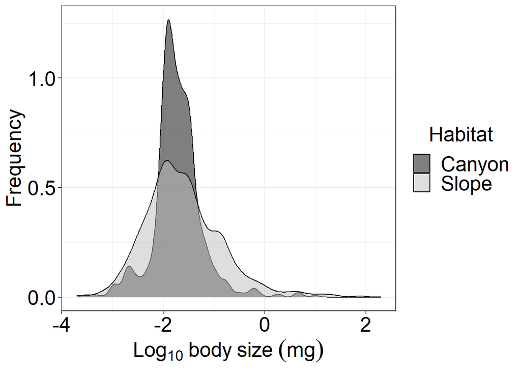

```r
# Use functions from Edwards etal. (2017) Methods in Ecology and Evolution 1:57-67
# https://github.com/andrew-edwards/fitting-size-spectra
#source("PLBfunctions.r")

hab <- splitBy(~Habitat, data=subset(mac_s, Condition=="C"))
wt <- lapply(hab, FUN=function(x)x$Wt)
bks <- l2b(unlist(wt))
out <- lapply(wt, FUN=function(x)LBNbiom.method(x, binBreaks=bks))
nbss <- ldply(lapply(out, FUN=function(x)x$binVals), data.frame)
info <- ldply(strsplit(nbss$.id, split="[|]"))
names(info) <- c("Habitat")
nbss <- cbind(info, nbss[, -1])

ggplot(data=ldply(hab),
       aes(x=log10(Wt), fill=Habitat))+
  geom_density(alpha=0.5)+
  scale_fill_manual(values=c("black", "gray"))+
  labs(y="Frequency", x=expression(Log[10]~body~size~(mg)))+
  theme_bw() %+replace% large #%+replace% dark
```

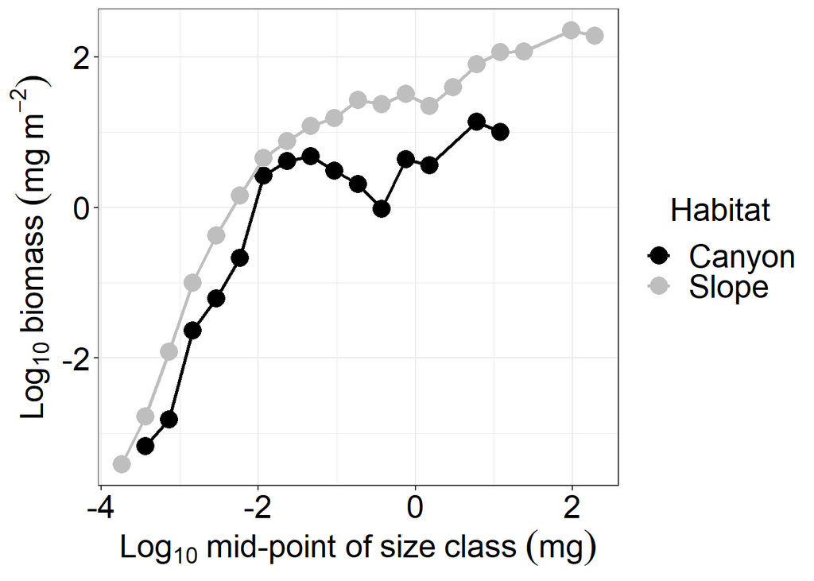

```r
ggplot(data=nbss,aes(x=log10binMid, y=log10totalBiom, colour=Habitat))+
  geom_point(size=5)+
  geom_path(size=1)+
  scale_colour_manual(values=c("black","gray"))+
  labs(x=expression(Log[10]~"mid-point of"~size~class~(mg)), y=expression(Log[10]~biomass~(mg~m^-2)))+
  theme_bw() %+replace% large #%+replace% dark
```

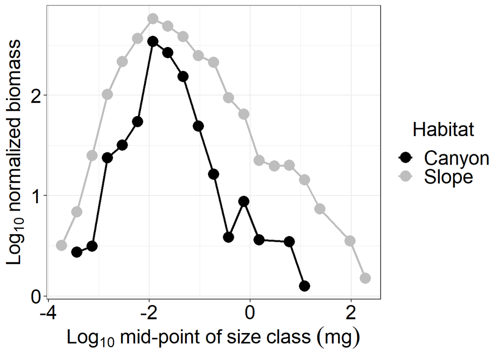

```r
ggplot(data=nbss,aes(x=log10binMid, y=log10totalBiomNorm, colour=Habitat))+
  geom_point(size=5)+
  geom_path(size=1)+
  scale_colour_manual(values=c("black","gray"))+
  labs(x=expression(Log[10]~"mid-point of"~size~class~(mg)), y=expression(Log[10]~normalized~biomass))+
  theme_bw() %+replace% large #%+replace% dark
```

## 2.2 Size classes >= 1e-02

```r
# Only keep Wt > 1e-02

hab <- splitBy(~Habitat, data=subset(mac_s, Condition=="C" &Wt>=1e-02))
wt <- lapply(hab, FUN=function(x)x$Wt)
out <- lapply(wt, FUN=function(x)LBNbiom.method(x, binBreaks=bks))
nbss <- ldply(lapply(out, FUN=function(x)x$binVals), data.frame)
info <- ldply(strsplit(nbss$.id, split="[|]"))
names(info) <- c("Habitat")
nbss <- cbind(info, nbss[, -1])

out <- lapply(wt, FUN=MLE.method)
# size specutrum slope estimate by MLE
lapply(out, FUN=function(x)x[1:2])
```

```
## $Canyon
## $Canyon$PLB.bMLE
## [1] -2.02386
##
## $Canyon$PLB.MLE.bConf
## [1] -2.11405 -1.93814
##
##
## $Slope
## $Slope$PLB.bMLE
## [1] -1.574413
##
## $Slope$PLB.MLE.bConf
## [1] -1.606953 -1.542793
```

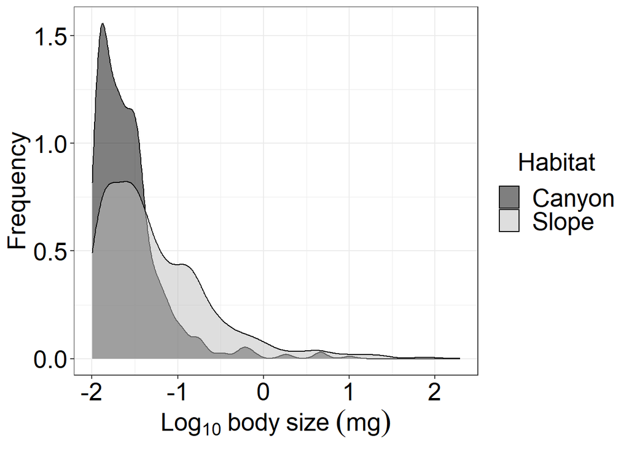

```r
plb <- ldply(lapply(out, FUN=function(x)x$PLB))
info <- ldply(strsplit(plb$.id, split="[|]"))
names(info) <- c("Habitat")
plb <- cbind(info, plb[, -1])

ggplot(data=ldply(hab),
       aes(x=log10(Wt), fill=Habitat))+
  geom_density(alpha=0.5)+
  scale_fill_manual(values=c("black", "gray"))+
  labs(y="Frequency", x=expression(Log[10]~body~size~(mg)))+
  theme_bw() %+replace% large #%+replace% dark
```

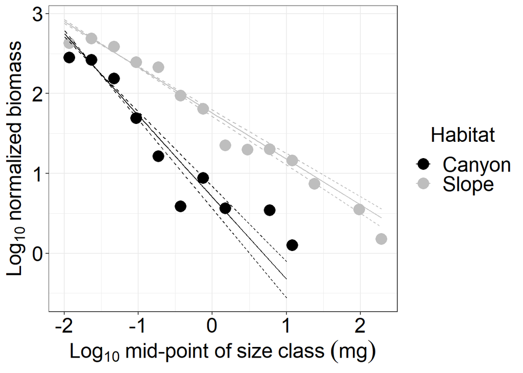

```r
ggplot(data=nbss,aes(x=log10binMid, y=log10totalBiomNorm, colour=Habitat))+
  geom_point(size=5)+
  geom_path(data=plb, aes(x=log10(x.PLB), y=log10(B.PLB)))+
  geom_path(data=plb, aes(x=log10(x.PLB), y=log10(B.PLB.LC)), linetype=2)+
  geom_path(data=plb, aes(x=log10(x.PLB), y=log10(B.PLB.UC)), linetype=2)+
  scale_colour_manual(values=c("black","gray"))+
  labs(x=expression(Log[10]~"mid-point of"~size~class~(mg)), y=expression(Log[10]~normalized~biomass))+
  theme_bw() %+replace% large #%+replace% dark
```

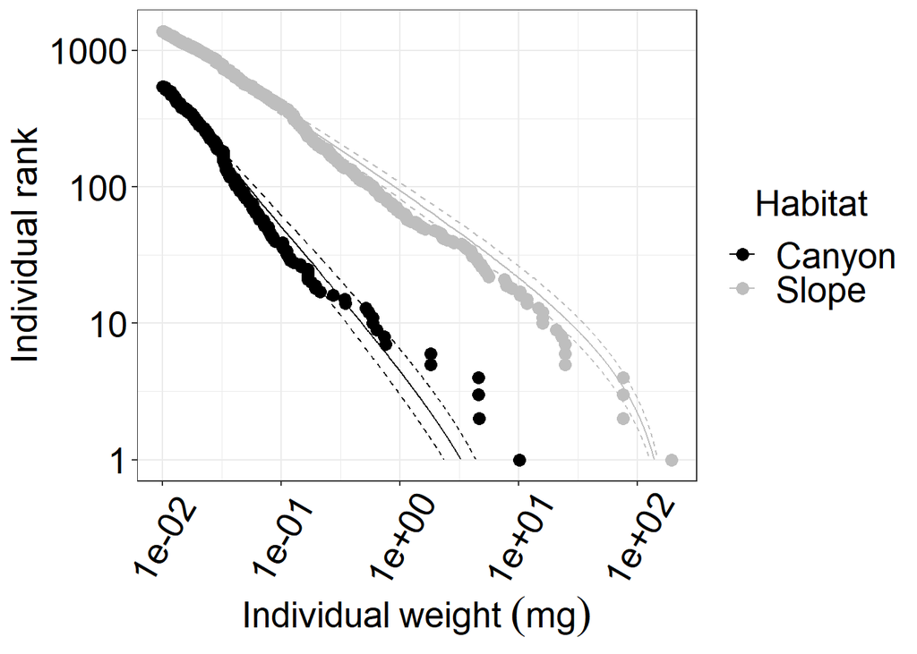

```r
# Rank individual weight
SortWt <- lapply(hab, FUN=function(x)cbind(rank=1:length(x$Wt), weight=sort(x$Wt, decreasing=TRUE)))
SortWt <- ldply(SortWt)
info <- ldply(strsplit(SortWt$.id, split="[|]"))
names(info) <- c("Habitat")
SortWt <- cbind(info, SortWt[, -1])

ggplot(data=SortWt, aes(x=weight, y=rank, colour=Habitat))+
  geom_point(size=3)+
  geom_path(data=plb, aes(x=x.PLB, y=y.PLB))+
  geom_path(data=plb, aes(x=x.PLB, y=y.PLB.LC), linetype=2)+
  geom_path(data=plb, aes(x=x.PLB, y=y.PLB.UC), linetype=2)+
  scale_colour_manual(values=c("black","gray"))+
  scale_x_log10(expression(Individual~weight~(mg)))+
  scale_y_log10("Individual rank", limits=c(1, NA))+
  theme_bw() %+replace% large %+replace% rotate #%+replace% dark
```

# 3 NBSS and ISD by cruise and habitat

## 3.1 All size classes

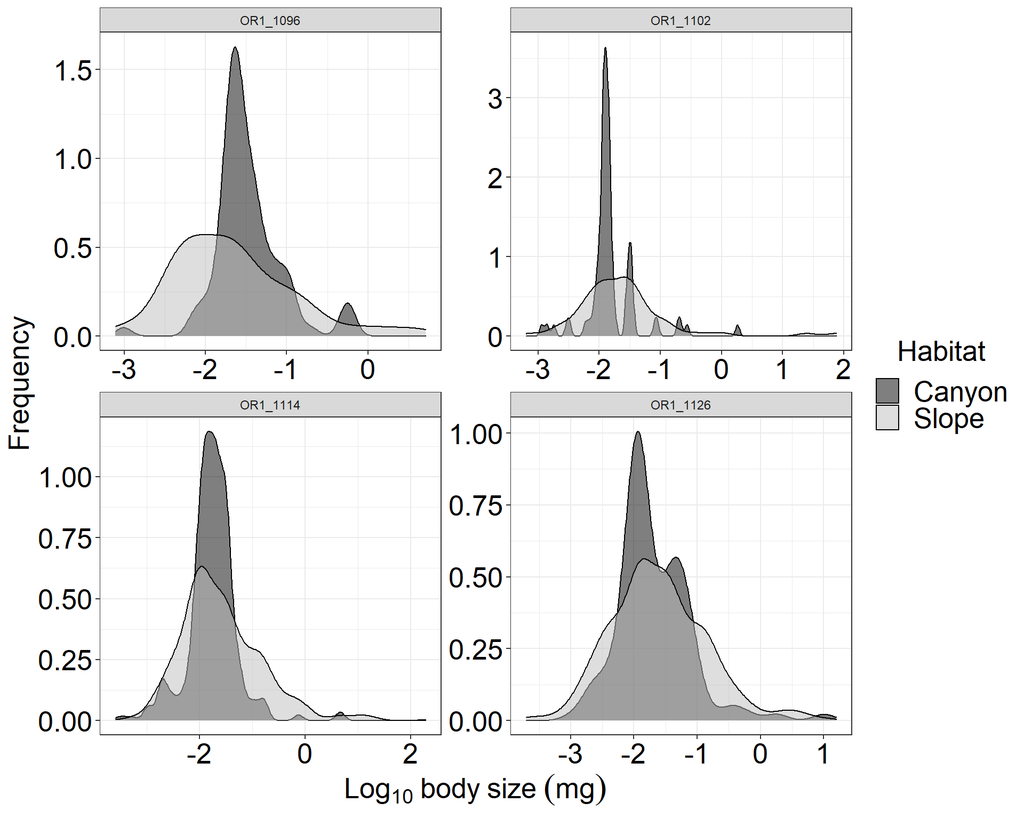

```r
hab <- splitBy(~Cruise+Habitat, data=subset(mac_s, Condition=="C"))
wt <- lapply(hab, FUN=function(x)x$Wt)
out <- lapply(wt, FUN=function(x)LBNbiom.method(x, binBreaks=bks))
nbss <- ldply(lapply(out, FUN=function(x)x$binVals), data.frame)
info <- ldply(strsplit(nbss$.id, split="[|]"))
names(info) <- c("Cruise", "Habitat")
nbss <- cbind(info, nbss[, -1])

ggplot(data=ldply(hab),
       aes(x=log10(Wt), fill=Habitat))+
  geom_density(alpha=0.5)+
  scale_fill_manual(values=c("black", "gray"))+
  facet_wrap(~Cruise, scales="free")+
  labs(y="Frequency", x=expression(Log[10]~body~size~(mg)))+
  theme_bw() %+replace% large #%+replace% dark
```

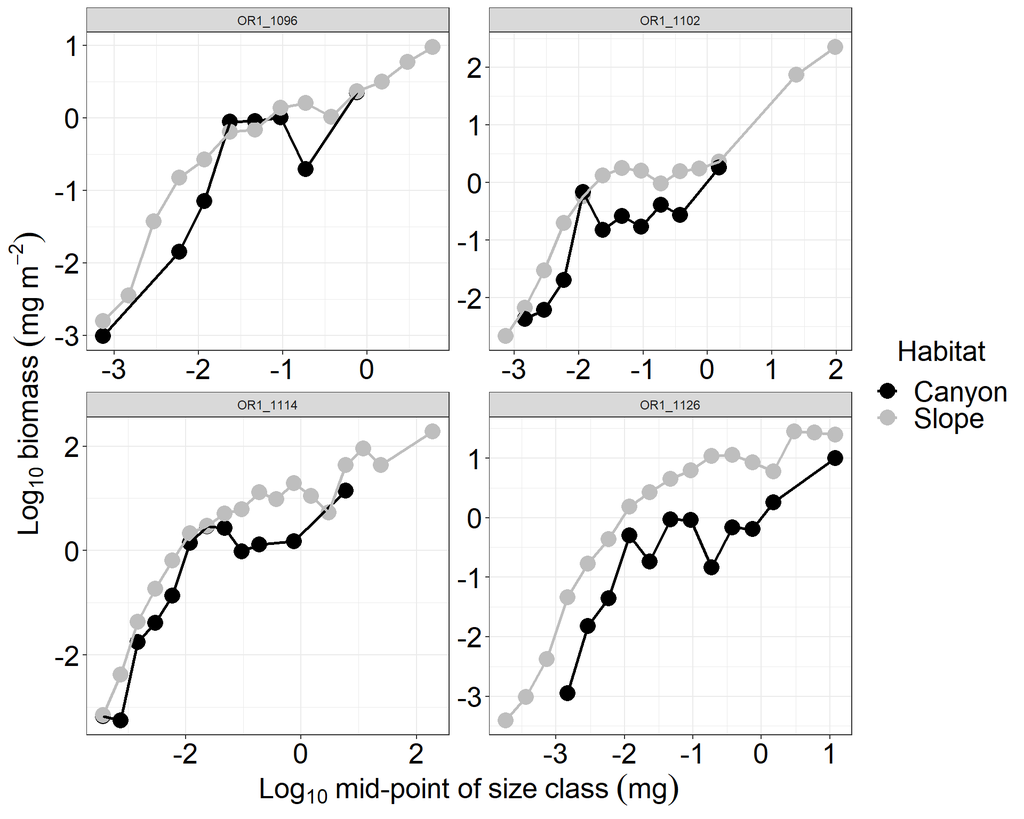

```r
ggplot(data=nbss,aes(x=log10binMid, y=log10totalBiom, colour=Habitat))+
  geom_point(size=5)+
  geom_path(size=1)+
  facet_wrap(~Cruise, scales="free")+
  scale_colour_manual(values=c("black","gray"))+
  labs(x=expression(Log[10]~"mid-point of"~size~class~(mg)), y=expression(Log[10]~biomass~(mg~m^-2)))+
  theme_bw() %+replace% large #%+replace% dark
```

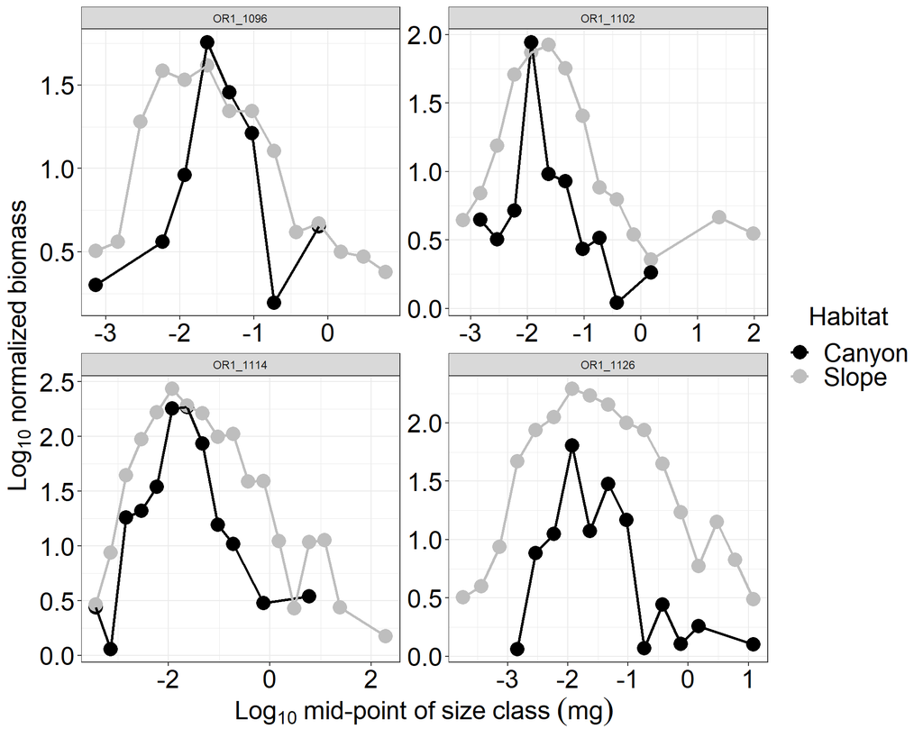

```r
ggplot(data=nbss,aes(x=log10binMid, y=log10totalBiomNorm, colour=Habitat))+
  geom_point(size=5)+
  geom_path(size=1)+
  facet_wrap(~Cruise, scales="free")+
  scale_colour_manual(values=c("black","gray"))+
  labs(x=expression(Log[10]~"mid-point of"~size~class~(mg)), y=expression(Log[10]~normalized~biomass))+
  theme_bw() %+replace% large #%+replace% dark
```

## 3.2 Size classes >= 1e-02

```r
# Only keep Wt >= 1e-02

hab <- splitBy(~Cruise+Habitat, data=subset(mac_s, Condition=="C" & Wt>= 1e-02))
wt <- lapply(hab, FUN=function(x)x$Wt)
out <- lapply(wt, FUN=function(x)LBNbiom.method(x, binBreaks=bks))
nbss <- ldply(lapply(out, FUN=function(x)x$binVals), data.frame)
info <- ldply(strsplit(nbss$.id, split="[|]"))
names(info) <- c("Cruise", "Habitat")
nbss <- cbind(info, nbss[, -1])

wt <- wt[unlist(lapply(wt, length))>3]
out <- lapply(wt, FUN=MLE.method)
# size specutrum slope estimate by MLE
lapply(out, FUN=function(x)x[1:2])
```

```
## $`OR1_1096|Canyon`
## $`OR1_1096|Canyon`$PLB.bMLE
## [1] -1.618932
##
## $`OR1_1096|Canyon`$PLB.MLE.bConf
## [1] -1.840462 -1.410382
##
##
## $`OR1_1096|Slope`
## $`OR1_1096|Slope`$PLB.bMLE
## [1] -1.490824
##
## $`OR1_1096|Slope`$PLB.MLE.bConf
## [1] -1.633104 -1.357854
##
##
## $`OR1_1102|Slope`
## $`OR1_1102|Slope`$PLB.bMLE
## [1] -1.66183
##
## $`OR1_1102|Slope`$PLB.MLE.bConf
## [1] -1.77307 -1.55962
##
##
## $`OR1_1114|Canyon`
## $`OR1_1114|Canyon`$PLB.bMLE
## [1] -2.095246
##
## $`OR1_1114|Canyon`$PLB.MLE.bConf
## [1] -2.224446 -1.974246
##
##
## $`OR1_1114|Slope`
## $`OR1_1114|Slope`$PLB.bMLE
## [1] -1.553293
##
## $`OR1_1114|Slope`$PLB.MLE.bConf
## [1] -1.601533 -1.507053
##
##
## $`OR1_1126|Canyon`
## $`OR1_1126|Canyon`$PLB.bMLE
## [1] -1.855381
##
## $`OR1_1126|Canyon`$PLB.MLE.bConf
## [1] -2.063601 -1.670801
##
##
## $`OR1_1126|Slope`
## $`OR1_1126|Slope`$PLB.bMLE
## [1] -1.554587
##
## $`OR1_1126|Slope`$PLB.MLE.bConf
## [1] -1.612127 -1.499127
##
##
## $`OR1_1102|Canyon`
## $`OR1_1102|Canyon`$PLB.bMLE
## [1] -2.657945
##
## $`OR1_1102|Canyon`$PLB.MLE.bConf
## [1] -3.082575 -2.292615
```

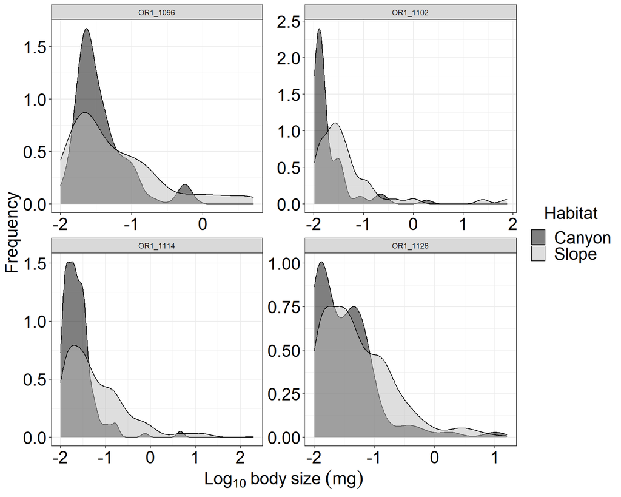

```r
plb <- ldply(lapply(out, FUN=function(x)x$PLB))
info <- ldply(strsplit(plb$.id, split="[|]"))
names(info) <- c("Cruise", "Habitat")
plb <- cbind(info, plb[, -1])

ggplot(data=ldply(hab),
       aes(x=log10(Wt), fill=Habitat))+
  geom_density(alpha=0.5)+
  scale_fill_manual(values=c("black", "gray"))+
  facet_wrap(~Cruise, scales="free")+
  labs(y="Frequency", x=expression(Log[10]~body~size~(mg)))+
  theme_bw() %+replace% large #%+replace% dark
```

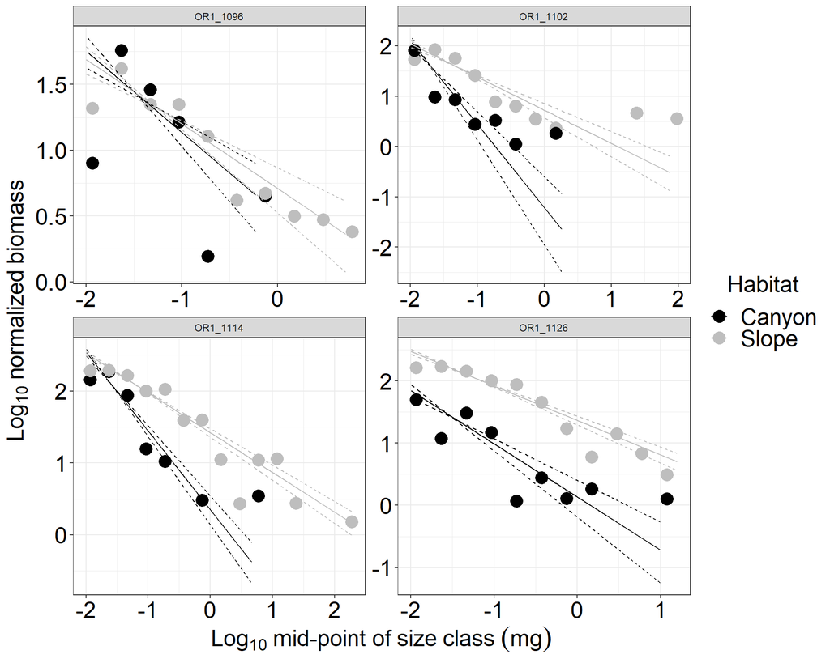

```r
ggplot(data=nbss,aes(x=log10binMid, y=log10totalBiomNorm, colour=Habitat))+
  geom_point(size=5)+
  geom_path(data=plb, aes(x=log10(x.PLB), y=log10(B.PLB)))+
  geom_path(data=plb, aes(x=log10(x.PLB), y=log10(B.PLB.LC)), linetype=2)+
  geom_path(data=plb, aes(x=log10(x.PLB), y=log10(B.PLB.UC)), linetype=2)+
  facet_wrap(~Cruise, scales="free")+
  scale_colour_manual(values=c("black","gray"))+
  labs(x=expression(Log[10]~"mid-point of"~size~class~(mg)), y=expression(Log[10]~normalized~biomass))+
  theme_bw() %+replace% large #%+replace% dark
```

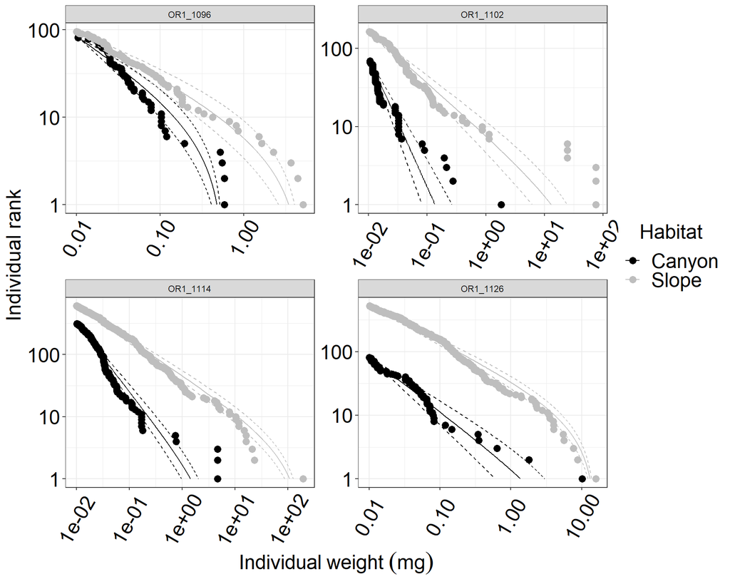

```r
# Rank individual weight
SortWt <- lapply(hab, FUN=function(x)cbind(rank=1:length(x$Wt), weight=sort(x$Wt, decreasing=TRUE)))
SortWt <- ldply(SortWt)
info <- ldply(strsplit(SortWt$.id, split="[|]"))
names(info) <- c("Cruise", "Habitat")
SortWt <- cbind(info, SortWt[, -1])

ggplot(data=SortWt, aes(x=weight, y=rank, colour=Habitat))+
  geom_point(size=3)+
  geom_path(data=plb, aes(x=x.PLB, y=y.PLB))+
  geom_path(data=plb, aes(x=x.PLB, y=y.PLB.LC), linetype=2)+
  geom_path(data=plb, aes(x=x.PLB, y=y.PLB.UC), linetype=2)+
  scale_colour_manual(values=c("black","gray"))+
  facet_wrap(~Cruise, scales="free")+
  scale_x_log10(expression(Individual~weight~(mg)))+
  scale_y_log10("Individual rank", limits=c(1, NA))+
  theme_bw() %+replace% large %+replace% rotate #%+replace% dark
```

# 4 NBSS and ISD by habitat and depth strata

## 4.1 All size classes

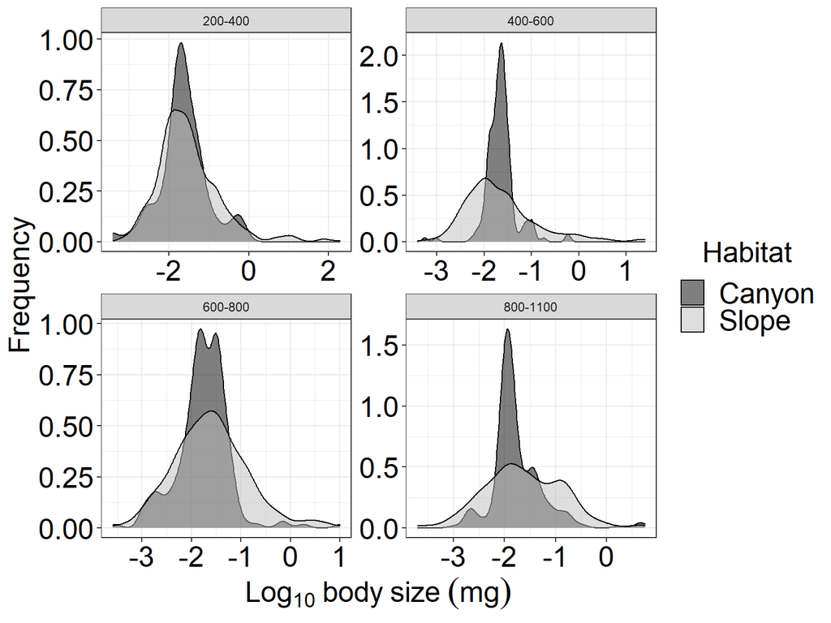

```r
hab <- splitBy(~Habitat+Depth.zone, data=subset(mac_s, Condition=="C"))
wt <- lapply(hab, FUN=function(x)x$Wt)
out <- lapply(wt, FUN=function(x)LBNbiom.method(x, binBreaks=bks))
nbss <- ldply(lapply(out, FUN=function(x)x$binVals), data.frame)
info <- ldply(strsplit(nbss$.id, split="[|]"))
names(info) <- c("Habitat", "Depth")
nbss <- cbind(info, nbss[, -1])

ggplot(data=ldply(hab),
       aes(x=log10(Wt), fill=Habitat))+
  geom_density(alpha=0.5)+
  scale_fill_manual(values=c("black", "gray"))+
  facet_wrap(~Depth.zone, scales="free")+
  labs(y="Frequency", x=expression(Log[10]~body~size~(mg)))+
  theme_bw() %+replace% large #%+replace% dark
```

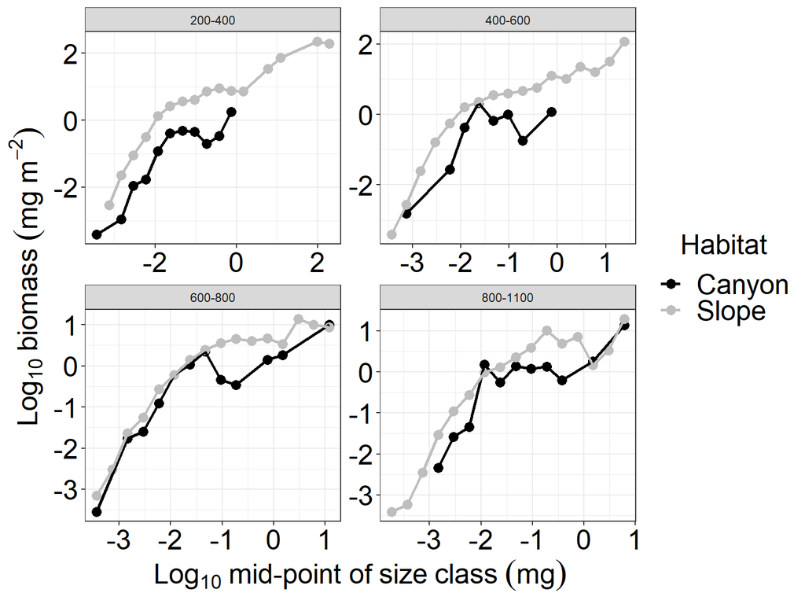

```r
ggplot(data=nbss, aes(x=log10binMid, y=log10totalBiom, colour=Habitat))+
  geom_point(size=3)+
  geom_path(size=1)+
  scale_colour_manual(values=c("black","gray"))+
  facet_wrap(~Depth, scales="free")+
  labs(x=expression(Log[10]~"mid-point of"~size~class~(mg)), y=expression(Log[10]~biomass~(mg~m^-2)))+
  theme_bw()%+replace% large #%+replace% dark
```

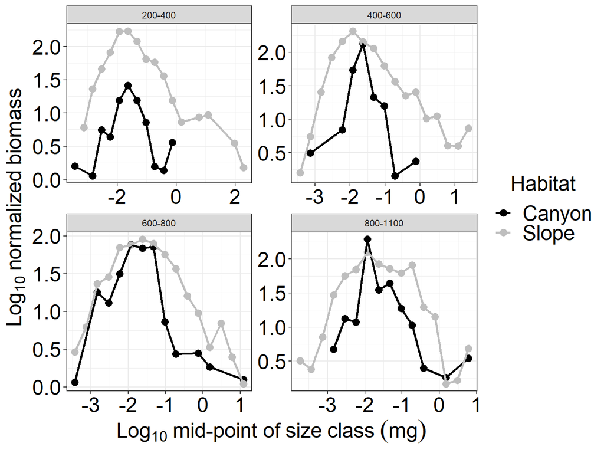

```r
ggplot(data=nbss, aes(x=log10binMid, y=log10totalBiomNorm, colour=Habitat))+
  geom_point(size=3)+
  geom_path(size=1)+
  scale_colour_manual(values=c("black","gray"))+
  facet_wrap(~Depth, scales="free")+
  labs(x=expression(Log[10]~"mid-point of"~size~class~(mg)), y=expression(Log[10]~normalized~biomass))+
  theme_bw()%+replace% large #%+replace% dark
```

## 4.2 Size classes >= 1e-02

```r
# Only keep Wt >= 1e-02

hab <- splitBy(~Habitat+Depth.zone, data=subset(mac_s, Condition=="C" & Wt>= 1e-02))
wt <- lapply(hab, FUN=function(x)x$Wt)
out <- lapply(wt, FUN=function(x)LBNbiom.method(x, binBreaks=bks))
nbss <- ldply(lapply(out, FUN=function(x)x$binVals), data.frame)
info <- ldply(strsplit(nbss$.id, split="[|]"))
names(info) <- c("Habitat", "Depth")
nbss <- cbind(info, nbss[, -1])

out <- lapply(wt, FUN=MLE.method)
# size specutrum slope estimate by MLE
lapply(out, FUN=function(x)x[1:2])
```

```
## $`Canyon|200-400`
## $`Canyon|200-400`$PLB.bMLE
## [1] -1.735809
##
## $`Canyon|200-400`$PLB.MLE.bConf
## [1] -2.040079 -1.459169
##
##
## $`Canyon|400-600`
## $`Canyon|400-600`$PLB.bMLE
## [1] -2.069317
##
## $`Canyon|400-600`$PLB.MLE.bConf
## [1] -2.269847 -1.882447
##
##
## $`Canyon|600-800`
## $`Canyon|600-800`$PLB.bMLE
## [1] -1.978789
##
## $`Canyon|600-800`$PLB.MLE.bConf
## [1] -2.144209 -1.828039
##
##
## $`Slope|200-400`
## $`Slope|200-400`$PLB.bMLE
## [1] -1.571175
##
## $`Slope|200-400`$PLB.MLE.bConf
## [1] -1.630425 -1.514885
##
##
## $`Slope|400-600`
## $`Slope|400-600`$PLB.bMLE
## [1] -1.571623
##
## $`Slope|400-600`$PLB.MLE.bConf
## [1] -1.636733 -1.509373
##
##
## $`Canyon|800-1100`
## $`Canyon|800-1100`$PLB.bMLE
## [1] -2.08548
##
## $`Canyon|800-1100`$PLB.MLE.bConf
## [1] -2.25454 -1.93024
##
##
## $`Slope|600-800`
## $`Slope|600-800`$PLB.bMLE
## [1] -1.530192
##
## $`Slope|600-800`$PLB.MLE.bConf
## [1] -1.615532 -1.448842
##
##
## $`Slope|800-1100`
## $`Slope|800-1100`$PLB.bMLE
## [1] -1.501486
##
## $`Slope|800-1100`$PLB.MLE.bConf
## [1] -1.579376 -1.426566
```

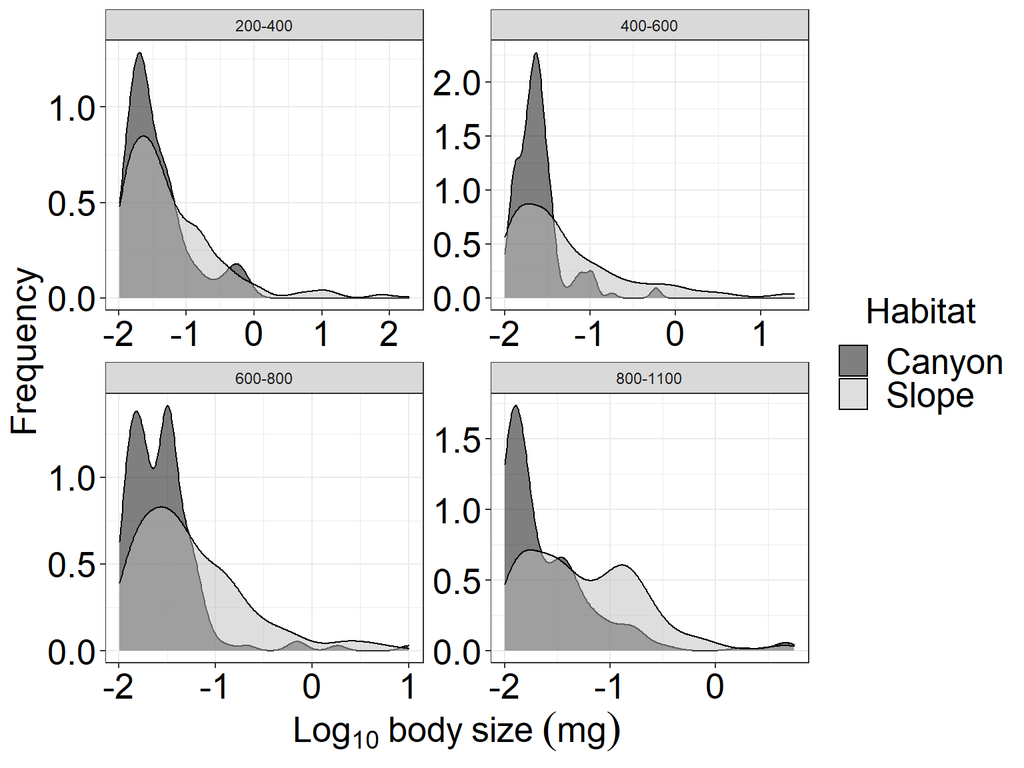

```r
plb <- ldply(lapply(out, FUN=function(x)x$PLB))
info <- ldply(strsplit(plb$.id, split="[|]"))
names(info) <- c("Habitat", "Depth")
plb <- cbind(info, plb[, -1])

ggplot(data=ldply(hab),
       aes(x=log10(Wt), fill=Habitat))+
  geom_density(alpha=0.5)+
  scale_fill_manual(values=c("black", "gray"))+
  facet_wrap(~Depth.zone, scales="free")+
  labs(y="Frequency", x=expression(Log[10]~body~size~(mg)))+
  theme_bw() %+replace% large #%+replace% dark
```

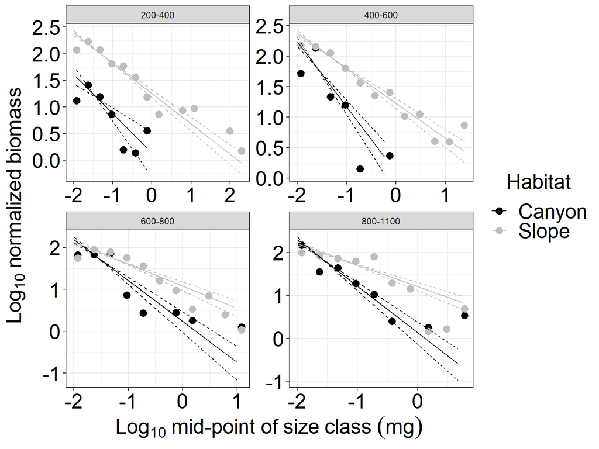

```r
ggplot(data=nbss, aes(x=log10binMid, y=log10totalBiomNorm, colour=Habitat))+
  geom_point(size=3)+
  scale_colour_manual(values=c("black","gray"))+
  geom_path(data=plb, aes(x=log10(x.PLB), y=log10(B.PLB)))+
  geom_path(data=plb, aes(x=log10(x.PLB), y=log10(B.PLB.LC)), linetype=2)+
  geom_path(data=plb, aes(x=log10(x.PLB), y=log10(B.PLB.UC)), linetype=2)+
  facet_wrap(~Depth, scales="free")+
  labs(x=expression(Log[10]~"mid-point of"~size~class~(mg)), y=expression(Log[10]~normalized~biomass))+
  theme_bw()%+replace% large #%+replace% dark
```

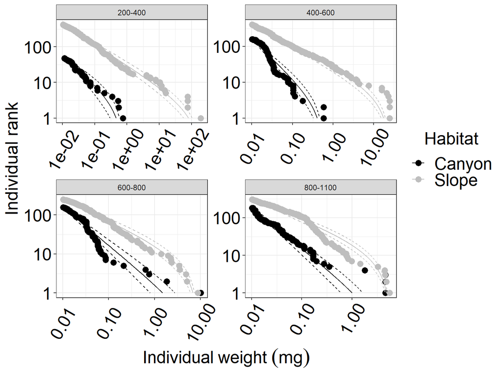

```r
# Rank individual weight
SortWt <- lapply(hab, FUN=function(x)cbind(rank=1:length(x$Wt), weight=sort(x$Wt, decreasing=TRUE)))
SortWt <- ldply(SortWt)
info <- ldply(strsplit(SortWt$.id, split="[|]"))
names(info) <- c("Habitat", "Depth")
SortWt <- cbind(info, SortWt[, -1])

ggplot(data=SortWt, aes(x=weight, y=rank, colour=Habitat))+
  geom_point(size=3)+
  geom_path(data=plb, aes(x=x.PLB, y=y.PLB))+
  geom_path(data=plb, aes(x=x.PLB, y=y.PLB.LC), linetype=2)+
  geom_path(data=plb, aes(x=x.PLB, y=y.PLB.UC), linetype=2)+
  scale_colour_manual(values=c("black","gray"))+
  facet_wrap(~Depth, scales="free")+
  scale_x_log10(expression(Individual~weight~(mg)))+
  scale_y_log10("Individual rank", limits=c(1, NA))+
  theme_bw() %+replace% large %+replace% rotate #%+replace% dark
```

# 5 NBSS and ISD by cruise, habitat and depth strata

## 5.1 All size classes

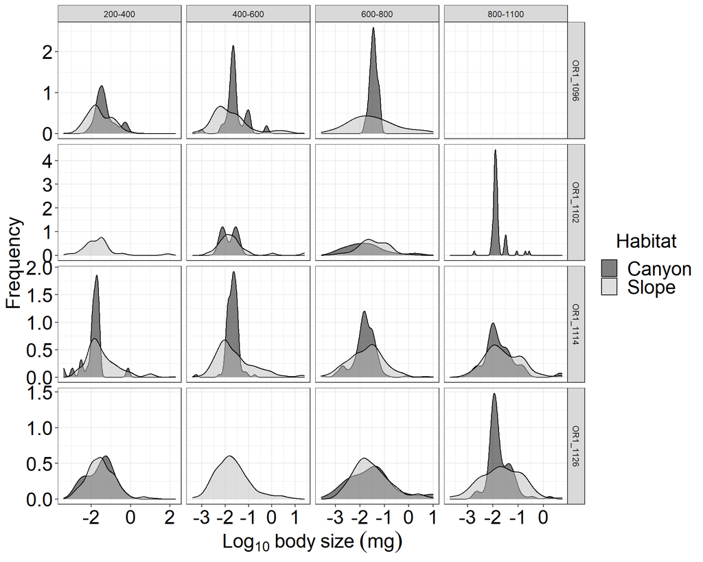

```r
hab <- splitBy(~Cruise+Habitat+Depth.zone, data=subset(mac_s, Condition=="C"))
wt <- lapply(hab, FUN=function(x)x$Wt)
out <- lapply(wt, FUN=function(x)LBNbiom.method(x, binBreaks=bks))
nbss <- ldply(lapply(out, FUN=function(x)x$binVals), data.frame)
info <- ldply(strsplit(nbss$.id, split="[|]"))
names(info) <- c("Cruise", "Habitat", "Depth")
nbss <- cbind(info, nbss[, -1])

ggplot(data=ldply(hab),
       aes(x=log10(Wt), fill=Habitat))+
  geom_density(alpha=0.5)+
  scale_fill_manual(values=c("black", "gray"))+
  facet_grid(Cruise~Depth.zone, scales="free")+
  labs(y="Frequency", x=expression(Log[10]~body~size~(mg)))+
  theme_bw() %+replace% large #%+replace% dark
```

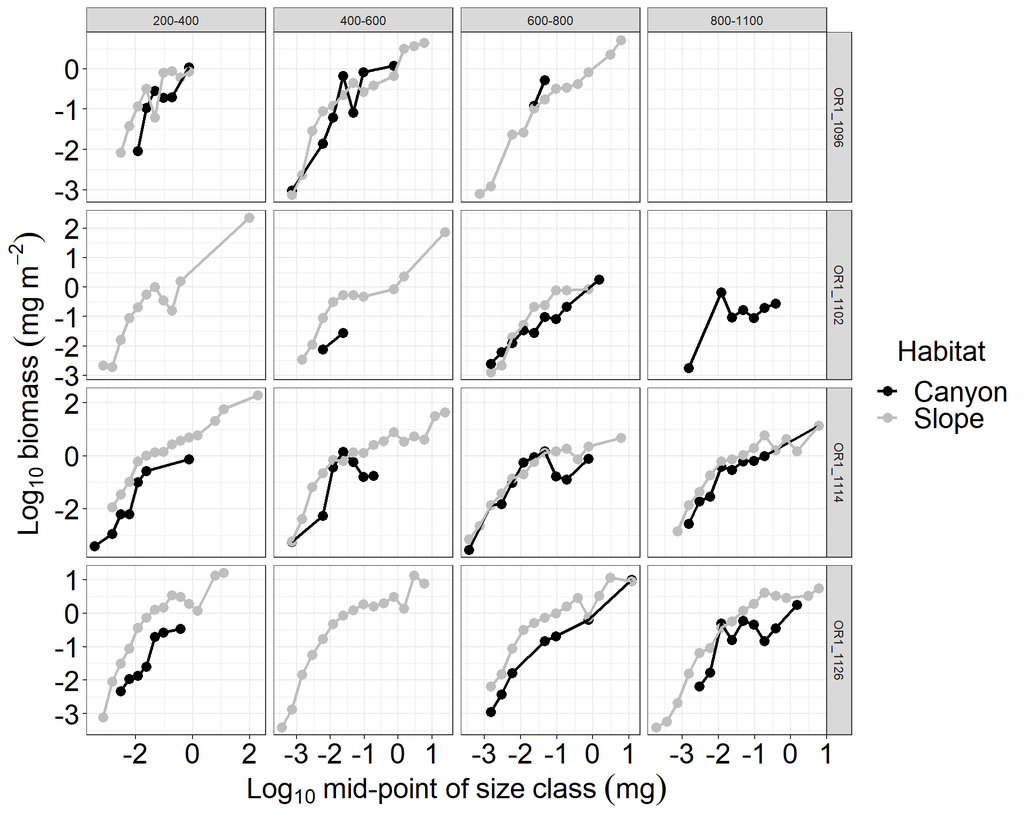

```r
ggplot(data=nbss, aes(x=log10binMid, y=log10totalBiom, colour=Habitat))+
  geom_point(size=3)+
  geom_path(size=1)+
  scale_colour_manual(values=c("black","gray"))+
  facet_grid(Cruise~Depth, scales="free")+
  labs(x=expression(Log[10]~"mid-point of"~size~class~(mg)), y=expression(Log[10]~biomass~(mg~m^-2)))+
  theme_bw()%+replace% large #%+replace% dark
```

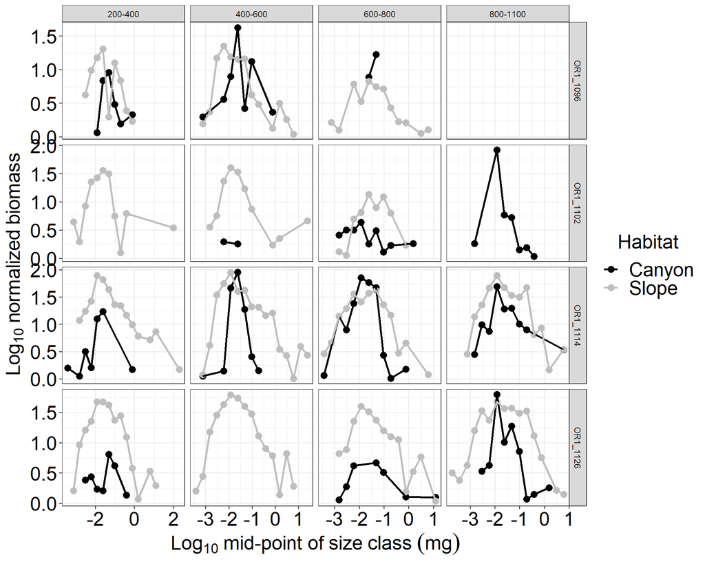

```r
ggplot(data=nbss, aes(x=log10binMid, y=log10totalBiomNorm, colour=Habitat))+
  geom_point(size=3)+
  geom_path(size=1)+
  scale_colour_manual(values=c("black","gray"))+
  facet_grid(Cruise~Depth, scales="free")+
  labs(x=expression(Log[10]~"mid-point of"~size~class~(mg)), y=expression(Log[10]~normalized~biomass))+
  theme_bw()%+replace% large #%+replace% dark
```

## 5.2 Size classes >= 1e-02

```r
# Only keep size >= 1e-02

hab <- splitBy(~Cruise+Habitat+Depth.zone, data=subset(mac_s, Wt >= 1e-02))
wt <- lapply(hab, FUN=function(x)x$Wt)
out <- lapply(wt, FUN=function(x)LBNbiom.method(x, binBreaks=bks))
nbss <- ldply(lapply(out, FUN=function(x)x$binVals), data.frame)
info <- ldply(strsplit(nbss$.id, split="[|]"))
names(info) <- c("Cruise", "Habitat", "Depth")
nbss <- cbind(info, nbss[, -1])

wt <- wt[unlist(lapply(wt, length))>62]
out <- lapply(wt, FUN=MLE.method)
# size specutrum slope estimate by MLE
lapply(out, FUN=function(x)x[1:2])
```

```
## $`OR1_1102|Slope|200-400`
## $`OR1_1102|Slope|200-400`$PLB.bMLE
## [1] -1.619669
##
## $`OR1_1102|Slope|200-400`$PLB.MLE.bConf
## [1] -1.788819 -1.470709
##
##
## $`OR1_1102|Slope|400-600`
## $`OR1_1102|Slope|400-600`$PLB.bMLE
## [1] -1.746296
##
## $`OR1_1102|Slope|400-600`$PLB.MLE.bConf
## [1] -1.953146 -1.565326
##
##
## $`OR1_1114|Canyon|400-600`
## $`OR1_1114|Canyon|400-600`$PLB.bMLE
## [1] -2.134428
##
## $`OR1_1114|Canyon|400-600`$PLB.MLE.bConf
## [1] -2.431088 -1.856998
##
##
## $`OR1_1114|Canyon|600-800`
## $`OR1_1114|Canyon|600-800`$PLB.bMLE
## [1] -2.174643
##
## $`OR1_1114|Canyon|600-800`$PLB.MLE.bConf
## [1] -2.414293 -1.955583
##
##
## $`OR1_1114|Slope|200-400`
## $`OR1_1114|Slope|200-400`$PLB.bMLE
## [1] -1.531433
##
## $`OR1_1114|Slope|200-400`$PLB.MLE.bConf
## [1] -1.619873 -1.449463
##
##
```

[output cut: 39 more lines]

```
##
## $`OR1_1126|Slope|600-800`
## $`OR1_1126|Slope|600-800`$PLB.bMLE
## [1] -1.489367
##
## $`OR1_1126|Slope|600-800`$PLB.MLE.bConf
## [1] -1.624897 -1.363307
##
##
## $`OR1_1126|Slope|800-1100`
## $`OR1_1126|Slope|800-1100`$PLB.bMLE
## [1] -1.492471
##
## $`OR1_1126|Slope|800-1100`$PLB.MLE.bConf
## [1] -1.608621 -1.382731
```

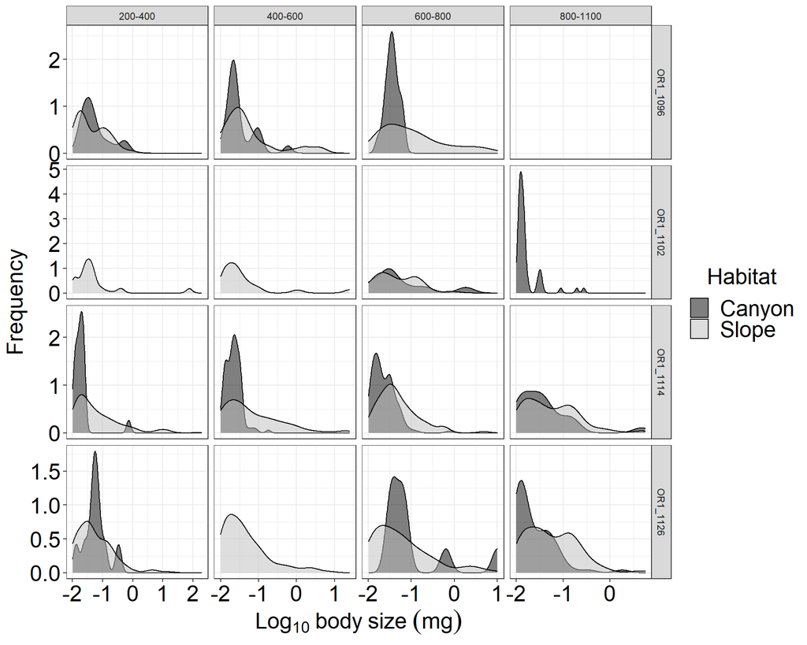

```r
plb <- ldply(lapply(out, FUN=function(x)x$PLB))
info <- ldply(strsplit(plb$.id, split="[|]"))
names(info) <- c("Cruise", "Habitat", "Depth")
plb <- cbind(info, plb[, -1])

ggplot(data=ldply(hab),
       aes(x=log10(Wt), fill=Habitat))+
  geom_density(alpha=0.5)+
  scale_fill_manual(values=c("black", "gray"))+
  facet_grid(Cruise~Depth.zone, scales="free")+
  labs(y="Frequency", x=expression(Log[10]~body~size~(mg)))+
  theme_bw() %+replace% large #%+replace% dark
```

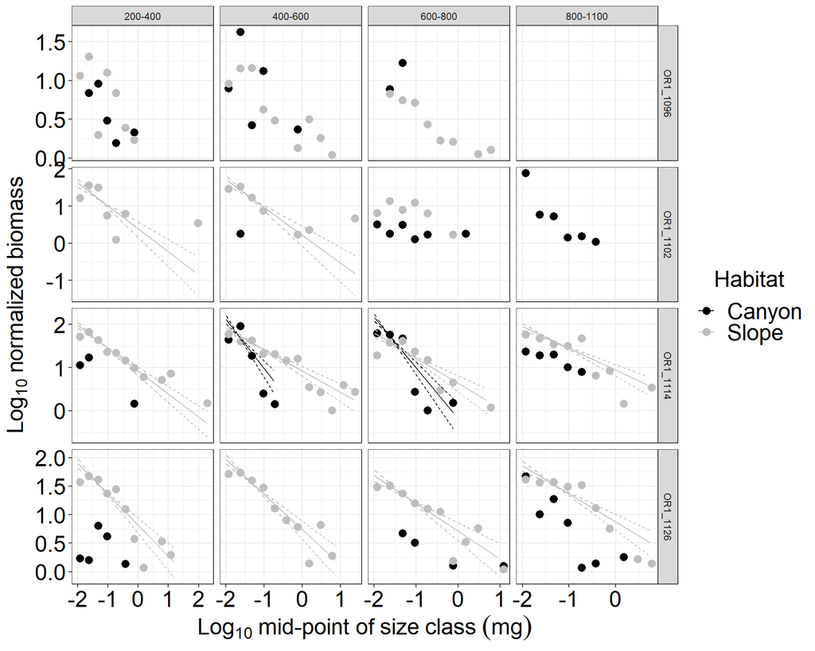

```r
ggplot(data=nbss, aes(x=log10binMid, y=log10totalBiomNorm, colour=Habitat))+
  geom_point(size=3)+
  scale_colour_manual(values=c("black","gray"))+
  geom_path(data=plb, aes(x=log10(x.PLB), y=log10(B.PLB)))+
  geom_path(data=plb, aes(x=log10(x.PLB), y=log10(B.PLB.LC)), linetype=2)+
  geom_path(data=plb, aes(x=log10(x.PLB), y=log10(B.PLB.UC)), linetype=2)+
  facet_grid(Cruise~Depth, scales="free")+
  labs(x=expression(Log[10]~"mid-point of"~size~class~(mg)), y=expression(Log[10]~normalized~biomass))+
  theme_bw()%+replace% large #%+replace% dark
```

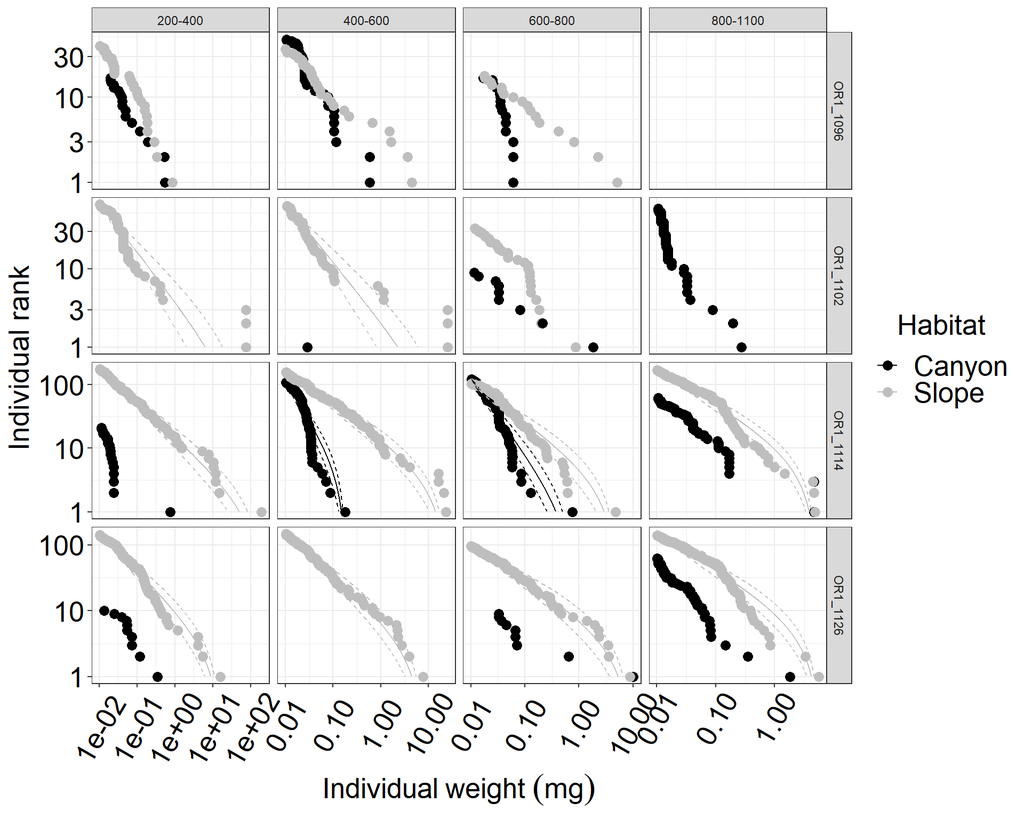

```r
# Rank individual weight
SortWt <- lapply(hab, FUN=function(x)cbind(rank=1:length(x$Wt), weight=sort(x$Wt, decreasing=TRUE)))
SortWt <- ldply(SortWt)
info <- ldply(strsplit(SortWt$.id, split="[|]"))
names(info) <- c("Cruise", "Habitat", "Depth")
SortWt <- cbind(info, SortWt[, -1])

ggplot(data=SortWt, aes(x=weight, y=rank, colour=Habitat))+
  geom_point(size=3)+
  geom_path(data=plb, aes(x=x.PLB, y=y.PLB))+
  geom_path(data=plb, aes(x=x.PLB, y=y.PLB.LC), linetype=2)+
  geom_path(data=plb, aes(x=x.PLB, y=y.PLB.UC), linetype=2)+
  scale_colour_manual(values=c("black","gray"))+
  facet_grid(Cruise~Depth, scales="free")+
  scale_x_log10(expression(Individual~weight~(mg)))+
  scale_y_log10("Individual rank", limits=c(1, NA))+
  theme_bw() %+replace% large %+replace% rotate #%+replace% dark
```

# 6 NBSS and ISD by habitat and dominant taxa

## 6.1 All size classes

```r
hab <- splitBy(~Habitat+Taxon, data=subset(mac_s, Condition=="C"))
wt <- lapply(hab, FUN=function(x)x$Wt)
out <- lapply(wt, FUN=function(x)LBNbiom.method(x, binBreaks=bks))
nbss <- ldply(lapply(out, FUN=function(x)x$binVals), data.frame)
info <- ldply(strsplit(nbss$.id, split="[|]"))
names(info) <- c("Habitat", "Taxon")
nbss <- cbind(info, nbss[, -1])

wt <- wt[unlist(lapply(wt, length))>8]
out <- lapply(wt, FUN=MLE.method)
# size specutrum slope estimate by MLE
lapply(out, FUN=function(x)x[1:2])
```

```
## $`Canyon|Polychaeta`
## $`Canyon|Polychaeta`$PLB.bMLE
## [1] -1.090883
##
## $`Canyon|Polychaeta`$PLB.MLE.bConf
## [1] -1.127633 -1.054563
##
##
## $`Slope|Polychaeta`
## $`Slope|Polychaeta`$PLB.bMLE
## [1] -1.307038
##
## $`Slope|Polychaeta`$PLB.MLE.bConf
## [1] -1.356778 -1.259108
##
##
## $`Slope|Amphipoda`
## $`Slope|Amphipoda`$PLB.bMLE
## [1] -1.068774
##
## $`Slope|Amphipoda`$PLB.MLE.bConf
## [1] -1.137514 -1.000754
##
##
## $`Slope|Isopoda`
## $`Slope|Isopoda`$PLB.bMLE
## [1] -1.10745
##
## $`Slope|Isopoda`$PLB.MLE.bConf
## [1] -1.14976 -1.06570
##
##
## $`Slope|Tanaidacea`
## $`Slope|Tanaidacea`$PLB.bMLE
## [1] -0.9365403
##
## $`Slope|Tanaidacea`$PLB.MLE.bConf
## [1] -0.9896803 -0.8831503
##
##
```

[output cut: 87 more lines]

```
##
## $`Slope|Nematoda`
## $`Slope|Nematoda`$PLB.bMLE
## [1] -1.031895
##
## $`Slope|Nematoda`$PLB.MLE.bConf
## [1] -1.1332954 -0.9307254
##
##
## $`Slope|Nemertea`
## $`Slope|Nemertea`$PLB.bMLE
## [1] -1.254094
##
## $`Slope|Nemertea`$PLB.MLE.bConf
## [1] -1.441784 -1.073764
```

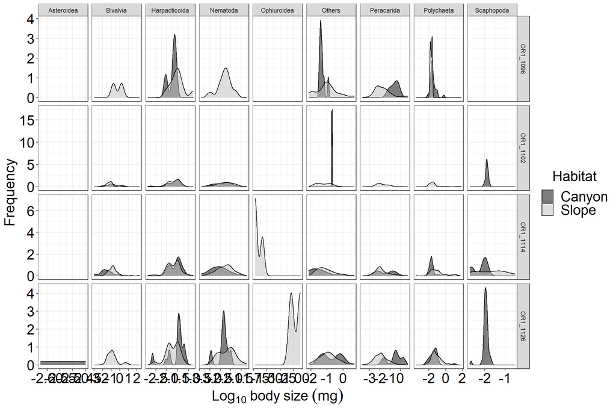

```r
plb <- ldply(lapply(out, FUN=function(x)x$PLB))
info <- ldply(strsplit(plb$.id, split="[|]"))
names(info) <- c("Habitat", "Taxon")
plb <- cbind(info, plb[, -1])

ggplot(data=ldply(hab),
       aes(x=log10(Wt), fill=Habitat))+
  geom_density(alpha=0.5)+
  scale_fill_manual(values=c("black", "gray"))+
  facet_grid(Cruise~Category, scales="free")+
  labs(y="Frequency", x=expression(Log[10]~body~size~(mg)))+
  theme_bw() %+replace% large #%+replace% dark
```

```
## geom_path: Each group consists of only one observation. Do you need to adjust
## the group aesthetic?
```

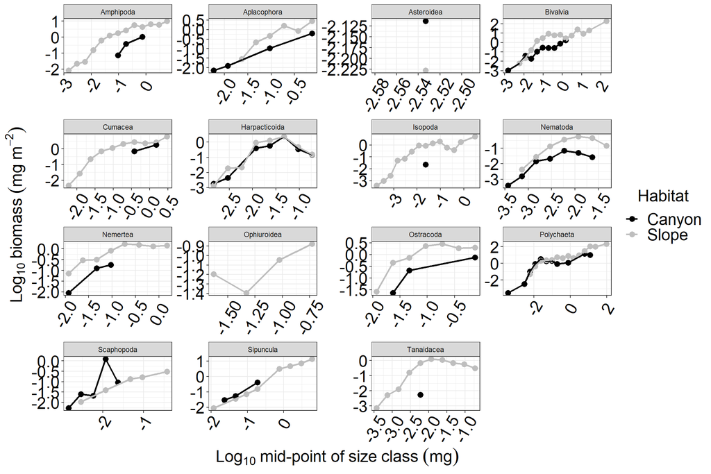

```r
ggplot(data=nbss, aes(x=log10binMid, y=log10totalBiom, colour=Habitat))+
  geom_point(size=3)+
  geom_path(size=1)+
  scale_colour_manual(values=c("black","gray"))+
  facet_wrap(~Taxon, scales="free")+
  labs(x=expression(Log[10]~"mid-point of"~size~class~(mg)), y=expression(Log[10]~biomass~(mg~m^-2)))+
  theme_bw()  %+replace% large  %+replace% rotate #%+replace% dark
```

```
## geom_path: Each group consists of only one observation. Do you need to adjust
## the group aesthetic?
```

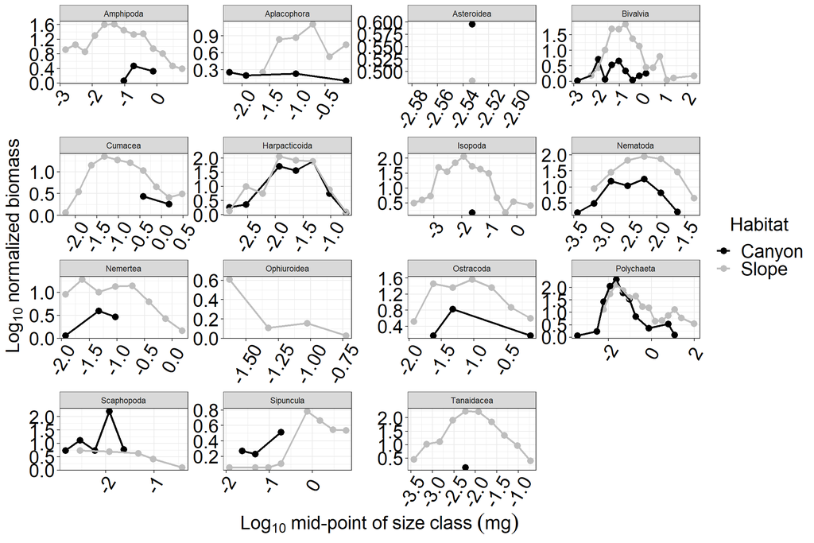

```r
ggplot(data=nbss, aes(x=log10binMid, y=log10totalBiomNorm, colour=Habitat))+
  geom_point(size=3)+
  geom_path(size=1)+
  scale_colour_manual(values=c("black","gray"))+
  #geom_path(data=plb, aes(x=log10(x.PLB), y=log10(B.PLB)))+
  #geom_path(data=plb, aes(x=log10(x.PLB), y=log10(B.PLB.LC)), linetype=2)+
  #geom_path(data=plb, aes(x=log10(x.PLB), y=log10(B.PLB.UC)), linetype=2)+
  facet_wrap(~Taxon, scales="free")+
  labs(x=expression(Log[10]~"mid-point of"~size~class~(mg)), y=expression(Log[10]~normalized~biomass))+
  theme_bw()  %+replace% large  %+replace% rotate #%+replace% dark
```

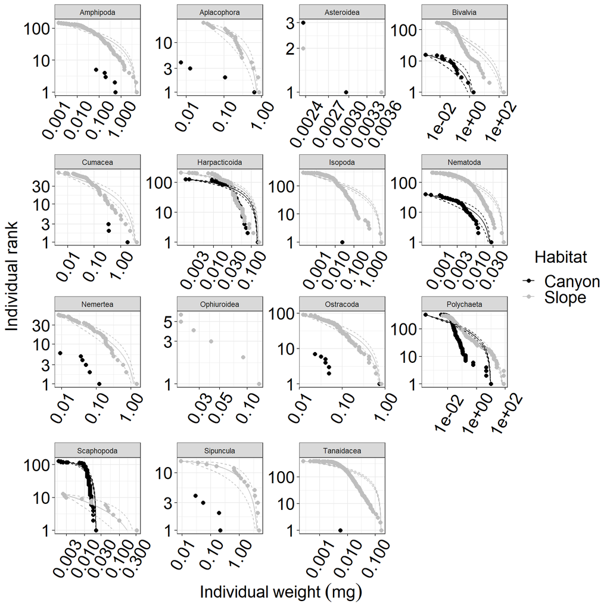

```r
# Rank individual weight
SortWt <- lapply(hab, FUN=function(x)cbind(rank=1:length(x$Wt), weight=sort(x$Wt, decreasing=TRUE)))
SortWt <- ldply(SortWt)
info <- ldply(strsplit(SortWt$.id, split="[|]"))
names(info) <- c("Habitat", "Taxon")
SortWt <- cbind(info, SortWt[, -1])

ggplot(data=SortWt, aes(x=weight, y=rank, colour=Habitat))+
  geom_point(size=2)+
  scale_colour_manual(values=c("black","gray"))+
  geom_path(data=plb, aes(x=x.PLB, y=y.PLB))+
  geom_path(data=plb, aes(x=x.PLB, y=y.PLB.LC), linetype=2)+
  geom_path(data=plb, aes(x=x.PLB, y=y.PLB.UC), linetype=2)+
  facet_wrap(~Taxon, scales="free")+
  scale_x_log10(expression(Individual~weight~(mg)))+
  scale_y_log10("Individual rank", limits=c(1, NA))+
  theme_bw()%+replace% large %+replace% rotate #%+replace% dark
```

# 7 Mean body size of macrofauna

## 7.1 By cruise and habitat

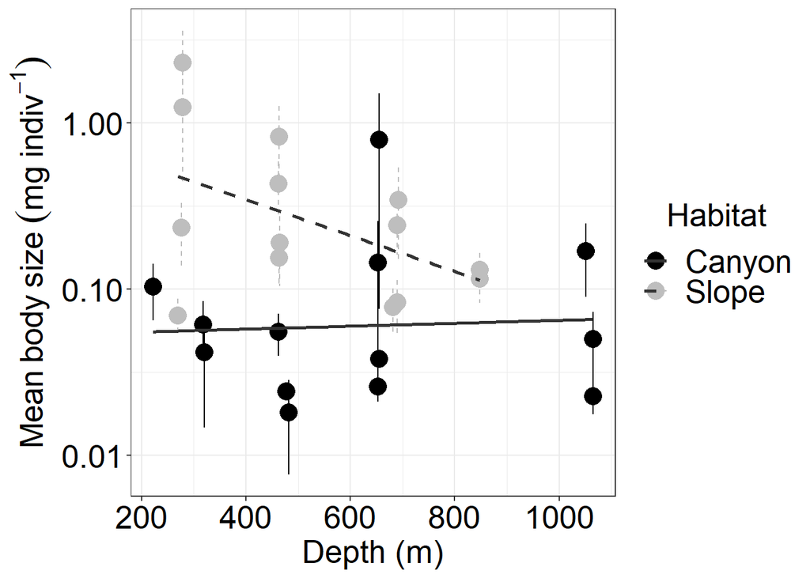

```r
library(knitr)
dat.mean <- summaryBy(Wt+Depth~Region+Habitat+Cruise+Station, data=subset(mac_s, Condition=="C"), FUN=c(mean, sd, length))
dat.mean$Wt.se <- dat.mean$Wt.sd/dat.mean$Wt.length^0.5
ggplot(data=dat.mean,
       aes(x=Depth.mean, y=Wt.mean,
           ymin=Wt.mean-Wt.se, ymax=Wt.mean+Wt.se,
           colour=Habitat, linetype=Habitat))+
  geom_point(size=5)+
  scale_colour_manual(values=c("black","gray"))+
  geom_errorbar()+
  stat_smooth(method="lm", formula=y~x, alpha=0.2, colour="gray20", se=FALSE)+
  scale_linetype_manual(values=c(1,2))+
  labs(x="Depth (m)", y=expression(Mean~body~size~(mg~indiv^-1)))+
  scale_y_log10()+
  theme_bw() %+replace% large
```

```r
out <- dat.mean[, c("Region", "Habitat", "Cruise", "Station", "Depth.mean", "Wt.length", "Wt.mean", "Wt.sd", "Wt.se")]
names(out) <- c("Region", "Habitat", "Cruise", "Station", "Depth", "n", "Mean Size", "SD", "SE")
out$Depth <- round(out$Depth, 0)
out$`Mean Size` <- round(out$`Mean Size`, 2)
out$SD <- round(out$SD, 3)
out$SE <- round(out$SE, 3)
kable(out, align="c")
```

| Region | Habitat | Cruise | Station | Depth | n | Mean Size | SD | SE |
| --- | --- | --- | --- | --- | --- | --- | --- | --- |
| Gaoping | Canyon | OR1_1096 | GC1 | 222 | 18 | 0.10 | 0.163 | 0.038 |
| Gaoping | Canyon | OR1_1096 | GC2 | 462 | 51 | 0.06 | 0.112 | 0.016 |
| Gaoping | Canyon | OR1_1096 | GC3 | 655 | 17 | 0.04 | 0.013 | 0.003 |
| Gaoping | Canyon | OR1_1102 | GC2 | 482 | 2 | 0.02 | 0.015 | 0.010 |
| Gaoping | Canyon | OR1_1102 | GC3 | 653 | 16 | 0.14 | 0.453 | 0.113 |
| Gaoping | Canyon | OR1_1102 | GC4 | 1065 | 65 | 0.02 | 0.040 | 0.005 |
| Gaoping | Canyon | OR1_1114 | GC1 | 320 | 27 | 0.04 | 0.140 | 0.027 |
| Gaoping | Canyon | OR1_1114 | GC2 | 478 | 112 | 0.02 | 0.019 | 0.002 |
| Gaoping | Canyon | OR1_1114 | GC3 | 653 | 160 | 0.03 | 0.061 | 0.005 |
| Gaoping | Canyon | OR1_1114 | GC4 | 1051 | 100 | 0.17 | 0.789 | 0.079 |
| Gaoping | Canyon | OR1_1126 | GC1 | 318 | 14 | 0.06 | 0.088 | 0.023 |
| Gaoping | Canyon | OR1_1126 | GC3 | 655 | 14 | 0.79 | 2.679 | 0.716 |
| Gaoping | Canyon | OR1_1126 | GC4 | 1065 | 80 | 0.05 | 0.204 | 0.023 |
| Gaoping | Slope | OR1_1096 | GS1 | 270 | 53 | 0.07 | 0.132 | 0.018 |
| Gaoping | Slope | OR1_1096 | GS2 | 465 | 71 | 0.19 | 0.718 | 0.085 |
| Gaoping | Slope | OR1_1096 | GS3 | 692 | 28 | 0.34 | 1.037 | 0.196 |
| Gaoping | Slope | OR1_1102 | GS1 | 279 | 100 | 2.30 | 12.898 | 1.290 |
| Gaoping | Slope | OR1_1102 | GS2 | 464 | 96 | 0.83 | 4.314 | 0.440 |
| Gaoping | Slope | OR1_1102 | GS3 | 682 | 38 | 0.08 | 0.142 | 0.023 |
| Gaoping | Slope | OR1_1114 | GS1 | 279 | 236 | 1.25 | 12.638 | 0.823 |
| Gaoping | Slope | OR1_1114 | GS2 | 462 | 249 | 0.43 | 2.433 | 0.154 |
| Gaoping | Slope | OR1_1114 | GS3 | 690 | 162 | 0.08 | 0.388 | 0.031 |
| Gaoping | Slope | OR1_1114 | GS4 | 848 | 244 | 0.13 | 0.527 | 0.034 |
| Gaoping | Slope | OR1_1126 | GS1 | 277 | 184 | 0.23 | 1.296 | 0.096 |
| Gaoping | Slope | OR1_1126 | GS2 | 463 | 219 | 0.15 | 0.665 | 0.045 |
| Gaoping | Slope | OR1_1126 | GS3 | 690 | 130 | 0.24 | 0.934 | 0.082 |
| Gaoping | Slope | OR1_1126 | GS4 | 848 | 203 | 0.12 | 0.465 | 0.033 |

## 7.2 By habitat

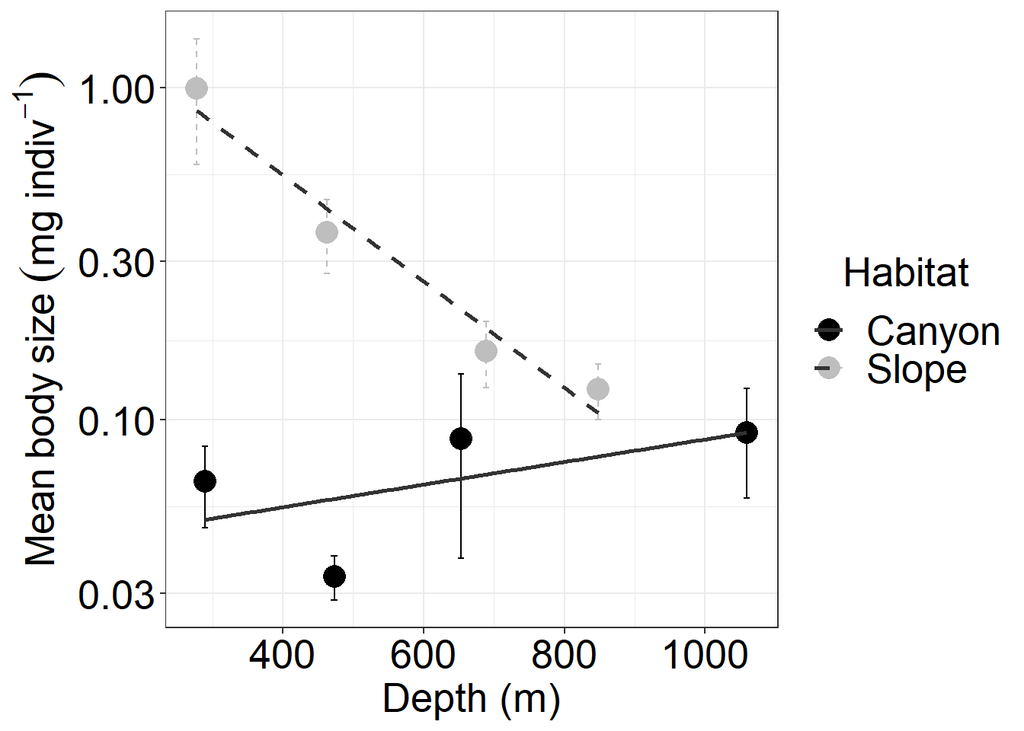

```r
dat.mean <- summaryBy(Wt+Depth~Region+Habitat+Station, data=mac_s, FUN=c(mean, sd, length))
dat.mean$Wt.se <- dat.mean$Wt.sd/dat.mean$Wt.length^0.5
ggplot(data=dat.mean,
       aes(x=Depth.mean, y=Wt.mean,
           ymin=Wt.mean-Wt.se, ymax=Wt.mean+Wt.se,
           colour=Habitat, linetype=Habitat))+
  geom_point(size=5)+
  scale_colour_manual(values=c("black","gray"))+
  geom_errorbar()+
  stat_smooth(method="lm", formula=y~x, alpha=0.2, colour="gray20", se=FALSE)+
  scale_linetype_manual(values=c(1,2))+
  labs(x="Depth (m)", y=expression(Mean~body~size~(mg~indiv^-1)))+
  scale_y_log10()+
  theme_bw() %+replace% large
```

```r
out <- dat.mean[, c("Region", "Habitat", "Station", "Depth.mean", "Wt.length", "Wt.mean", "Wt.sd", "Wt.se")]
names(out) <- c("Region", "Habitat", "Station", "Depth", "n", "Mean Size", "SD", "SE")
out$Depth <- round(out$Depth, 0)
out$`Mean Size` <- round(out$`Mean Size`, 2)
out$SD <- round(out$SD, 3)
out$SE <- round(out$SE, 3)
kable(out, align="c")
```

| Region | Habitat | Station | Depth | n | Mean Size | SD | SE |
| --- | --- | --- | --- | --- | --- | --- | --- |
| Gaoping | Canyon | GC1 | 290 | 59 | 0.07 | 0.138 | 0.018 |
| Gaoping | Canyon | GC2 | 473 | 165 | 0.03 | 0.066 | 0.005 |
| Gaoping | Canyon | GC3 | 653 | 207 | 0.09 | 0.713 | 0.050 |
| Gaoping | Canyon | GC4 | 1059 | 245 | 0.09 | 0.520 | 0.033 |
| Gaoping | Slope | GS1 | 277 | 573 | 1.00 | 9.774 | 0.408 |
| Gaoping | Slope | GS2 | 463 | 635 | 0.37 | 2.317 | 0.092 |
| Gaoping | Slope | GS3 | 689 | 358 | 0.16 | 0.689 | 0.036 |
| Gaoping | Slope | GS4 | 848 | 447 | 0.12 | 0.500 | 0.024 |